# finalyelp

```python
import numpy
```

```python
import pandas as pd
df = pd.read_csv('yelp_restaurant2.csv', encoding = "ISO-8859-1")
df
```

|  | company | location | source_url |
| --- | --- | --- | --- |
| 0 | Thursday Kitchen | 424 E 9th St New York, NY 10009 | https://www.yelp.com/search?find_desc=Restaura... |
| 1 | The Boil | 139 Chrystie St New York, NY 10002 | https://www.yelp.com/search?find_desc=Restaura... |
| 2 | Bep Ga | 70 Forsyth St New York, NY 10002 | https://www.yelp.com/search?find_desc=Restaura... |
| 3 | Thai Villa | 5 E 19th St New York, NY 10003 | https://www.yelp.com/search?find_desc=Restaura... |
| 4 | Dutch Freds | 307 W 47th St New York, NY 10036 | https://www.yelp.com/search?find_desc=Restaura... |
| 5 | Rocket Pig | 463 W 24th St New York, NY 10001 | https://www.yelp.com/search?find_desc=Restaura... |
| 6 | Purbird | 82 Sixth Ave Brooklyn, NY 11217 | https://www.yelp.com/search?find_desc=Restaura... |
| 7 | Whitmans Hudson Yards | 331 10th Ave New York, NY 10001 | https://www.yelp.com/search?find_desc=Restaura... |
| 8 | Los Tacos No.1 | 75 9th Ave New York, NY 10011 | https://www.yelp.com/search?find_desc=Restaura... |
| 9 | Chikarashi | 227 Canal St New York, NY 10013 | https://www.yelp.com/search?find_desc=Restaura... |
| 10 | Hollow Nickel | 494 Atlantic Ave Brooklyn, NY 11217 | https://www.yelp.com/search?find_desc=Restaura... |
| 11 | Simple NYC | 109 Eldridge St New York, NY 10002 | https://www.yelp.com/search?find_desc=Restaura... |
| 12 | East Coast Burgers | 53-21 Metropolitan Ave Ridgewood, NY 1... | https://www.yelp.com/search?find_desc=Restaura... |
| 13 | Topaz Noodle Bar | 129 W 56th St New York, NY 10019 | https://www.yelp.com/search?find_desc=Restaura... |
| 14 | Jack??s Wife Freda | 50 Carmine St New York, NY 10014 | https://www.yelp.com/search?find_desc=Restaura... |
| 15 | Five Leaves | 18 Bedford Ave Brooklyn, NY 11222 | https://www.yelp.com/search?find_desc=Restaura... |
| 16 | Cookshop | 156 10th Ave New York, NY 10011 | https://www.yelp.com/search?find_desc=Restaura... |
| 17 | Istanblue Kings Restaurant | 428 Kings Hwy Brooklyn, NY 11223 | https://www.yelp.com/search?find_desc=Restaura... |
| 18 | The Little Owl | 90 Bedford St New York, NY 10014 | https://www.yelp.com/search?find_desc=Restaura... |
| 19 | Hart??s Restaurant | 506 Franklin Ave New York, NY 11238 | https://www.yelp.com/search?find_desc=Restaura... |
| 20 | Upstate | 95 1st Ave New York, NY 10003 | https://www.yelp.com/search?find_desc=Restaura... |
| 21 | The Alcove | 41-11 49th St Sunnyside, NY 11104 | https://www.yelp.com/search?find_desc=Restaura... |
| 22 | Excellent Dumpling House | 165 W 23rd St New York, NY 10011 | https://www.yelp.com/search?find_desc=Restaura... |
| 23 | Am??lie | 22 W 8th St New York, NY 10011 | https://www.yelp.com/search?find_desc=Restaura... |
| 24 | Luke??s Lobster FiDi | 26 S William St New York, NY 10004 | https://www.yelp.com/search?find_desc=Restaura... |
| 25 | Burger & Lobster | 39 W 19th St New York, NY 10011 | https://www.yelp.com/search?find_desc=Restaura... |
| 26 | Cafe Mogador | 133 Wythe Ave Brooklyn, NY 11211 | https://www.yelp.com/search?find_desc=Restaura... |
| 27 | Blue Maiz | 606 8th Ave New York, NY 10018 | https://www.yelp.com/search?find_desc=Restaura... |
| 28 | Fishmarket Restaurant | 111 South St New York, NY 10038 | https://www.yelp.com/search?find_desc=Restaura... |
| 29 | Breakroom | 83 Baxter St New York, NY 10013 | https://www.yelp.com/search?find_desc=Restaura... |
| ... | ... | ... | ... |
| 119 | Jack??s Wife Freda | 224 Lafayette St New York, NY 10012 | https://www.yelp.com/search?find_desc=Restaura... |
| 120 | Joe??s Shanghai | 9 Pell St New York, NY 10013 | https://www.yelp.com/search?find_desc=Restaura... |
| 121 | Ltauha Restaurant | 55-50 Myrtle Ave Ridgewood, NY 11385 | https://www.yelp.com/search?find_desc=Restaura... |
| 122 | Poketeria | 3 E 36th St New York, NY 10016 | https://www.yelp.com/search?find_desc=Restaura... |
| 123 | Sweet Chick | 178 Ludlow St New York, NY 10002 | https://www.yelp.com/search?find_desc=Restaura... |
| 124 | Ippudo East Village | 65 4th Ave New York, NY 10003 | https://www.yelp.com/search?find_desc=Restaura... |
| 125 | Luke??s Lobster Brooklyn Bridge Park-DUMBO | 11 Water St Brooklyn, NY 11201 | https://www.yelp.com/search?find_desc=Restaura... |
| 126 | Olmsted | 659 Vanderbilt Ave Brooklyn, NY 11238 | https://www.yelp.com/search?find_desc=Restaura... |
| 127 | De Maria | 19 Kenmare St New York, NY 10012 | https://www.yelp.com/search?find_desc=Restaura... |
| 128 | Rubirosa | 235 Mulberry St New York, NY 10012 | https://www.yelp.com/search?find_desc=Restaura... |
| 129 | Saigon Shack | 114 Macdougal St New York, NY 10012 | https://www.yelp.com/search?find_desc=Restaura... |
| 130 | Palomas | 435 Menahan St Brooklyn, NY 11237 | https://www.yelp.com/search?find_desc=Restaura... |
| 131 | Pepe Rosso Social | 173 Mott St New York, NY 10013 | https://www.yelp.com/search?find_desc=Restaura... |
| 132 | Boqueria - Brooklyn | 590 Fulton St Brooklyn, NY 11217 | https://www.yelp.com/search?find_desc=Restaura... |
| 133 | Parker & Quinn | 64 W 39th St New York, NY 10018 | https://www.yelp.com/search?find_desc=Restaura... |
| 134 | PMF Pardon My French | 103 Ave B New York, NY 10009 | https://www.yelp.com/search?find_desc=Restaura... |
| 135 | VBar Seaport | 212 Front St New York, NY 10038 | https://www.yelp.com/search?find_desc=Restaura... |
| 136 | Trattoria Trecolori | 254 W 47th St New York, NY 10036 | https://www.yelp.com/search?find_desc=Restaura... |
| 137 | Kimbap Lab | 238 Bedford Ave Brooklyn, NY 11249 | https://www.yelp.com/search?find_desc=Restaura... |
| 138 | Wok Wok | 11 Mott St New York, NY 10013 | https://www.yelp.com/search?find_desc=Restaura... |
| 139 | Momosan Ramen & Sake | 342 Lexington Ave New York, NY 10016 | https://www.yelp.com/search?find_desc=Restaura... |
| 140 | The Cellar | 900 Broadway New York, NY 10003 | https://www.yelp.com/search?find_desc=Restaura... |
| 141 | Father Knows Best | 611A Wilson Ave Brooklyn, NY 11207 | https://www.yelp.com/search?find_desc=Restaura... |
| 142 | Sticky??s Finger Joint | 21 Maiden Ln New York, NY 10038 | https://www.yelp.com/search?find_desc=Restaura... |
| 143 | Montana??s Trail House | 445 Troutman St Brooklyn, NY 11237 | https://www.yelp.com/search?find_desc=Restaura... |
| 144 | Izakaya MEW | 53 W 35th St New York, NY 10001 | https://www.yelp.com/search?find_desc=Restaura... |
| 145 | Frankies 457 - Brooklyn | 457 Court St Brooklyn, NY 11231 | https://www.yelp.com/search?find_desc=Restaura... |
| 146 | Adrienne??s Pizzabar | 54 Stone St New York, NY 10004 | https://www.yelp.com/search?find_desc=Restaura... |
| 147 | Sinbad Seafood & Steak | 7721 5th Ave Brooklyn, NY 11209 | https://www.yelp.com/search?find_desc=Restaura... |
| 148 | L??Artusi | 228 W 10th St New York, NY 10014 | https://www.yelp.com/search?find_desc=Restaura... |

149 rows × 3 columns

```python
random_sample = df.sample(n=1)
random_sample
```

|  | company | location | source_url |
| --- | --- | --- | --- |
| 99 | The Food Sermon Kitchen | 355 Rogers Ave Brooklyn, NY 11225 | https://www.yelp.com/search?find_desc=Restaura... |

select the random number for the index

```python
import random
from random import randint
random_index = random.randint(0,150)
```

```python
print(random_index)
```

```
21
```

Define the restaurant's name, address and source url from the one selected data

```python
name = df.iloc[random_index,0]
address = df.iloc[random_index,1].strip()
source_url = df.iloc[random_index,2]
print(name,'\n',address,'\n',source_url)
```

```
The Alcove
 41-11 49th St Sunnyside, NY 11104
 https://www.yelp.com/search?find_desc=Restaurants&find_loc=New+York%2C+NY&ns=1
```

Open the source url by python

```python
from selenium import webdriver
driver = webdriver.Chrome('D:/courses/2017Spring/application references/chromedriver_win32/chromedriver.exe')
driver.get(source_url)
```

From the opened webpage, find out the restaurant we want and click to open it

```python
driver.find_element_by_link_text(name).click()
```

Scrape the restaurant's introduction webpage url from the source list url. Note that we need to scrape the one which has the same name with the one we have been selected.

```python
from urllib.request import urlopen
from bs4 import BeautifulSoup
import requests
import operator
import os
import matplotlib.pyplot as plt
from wordcloud import WordCloud
import re
```

```python
html = urlopen(source_url)
bs = BeautifulSoup(html, "lxml")

links = bs.find("div",{"class" : "search-results-content"}).findAll("a" , href=re.compile("(/biz/)+([A-Za-z0-9_:()])+"))

for link in links:
    print(link)
```

```
<a class="js-analytics-click" data-analytics-label="biz-photo" href="/biz/upstate-new-york-2?osq=Restaurants">
<img alt="Upstate" class="photo-box-img" height="90" src="https://s3-media1.fl.yelpcdn.com/bphoto/qJNkVkHcGWsprlouwX3siw/90s.jpg" width="90"/>
</a>
<a class="biz-name js-analytics-click" data-analytics-label="biz-name" data-hovercard-id="NWTcsDcRkkbADN0ctPtwrQ" href="/biz/upstate-new-york-2?osq=Restaurants"><span>Upstate</span></a>
<a class="nowrap" href="/biz/upstate-new-york-2?hrid=Nle09vgvLzhrvJntqLhBFg&amp;osq=Restaurants">read more</a>
<a class="js-analytics-click" data-analytics-label="biz-photo" href="/biz/the-alcove-sunnyside?osq=Restaurants">
<img alt="The Alcove" class="photo-box-img" height="90" src="https://s3-media1.fl.yelpcdn.com/bphoto/yerj0JC1KCT3z5MC02Qfdw/90s.jpg" width="90"/>
</a>
<a class="biz-name js-analytics-click" data-analytics-label="biz-name" data-hovercard-id="gNZvrTPR5NwQURFeUA1RYw" href="/biz/the-alcove-sunnyside?osq=Restaurants"><span>The Alcove</span></a>
<a class="nowrap" href="/biz/the-alcove-sunnyside?hrid=E_EUKw10kUseCjyvl8qk8A&amp;osq=Restaurants">read more</a>
<a class="js-analytics-click" data-analytics-label="biz-photo" href="/biz/bep-ga-new-york-4?osq=Restaurants">
<img alt="Bep Ga" class="photo-box-img" height="90" src="https://s3-media3.fl.yelpcdn.com/bphoto/pVym1sZ5aMMtktVgRds8vQ/90s.jpg" width="90"/>
</a>
<a class="biz-name js-analytics-click" data-analytics-label="biz-name" data-hovercard-id="ASqfOlNB0l_hftM4Fw66Qw" href="/biz/bep-ga-new-york-4?osq=Restaurants"><span>Bep Ga</span></a>
<a class="nowrap" href="/biz/bep-ga-new-york-4?hrid=xmMwgB7kdEn51PImwN40RA&amp;osq=Restaurants">read more</a>
<a class="js-analytics-click" data-analytics-label="biz-photo" href="/biz/am%C3%A9lie-new-york?osq=Restaurants">
<img alt="Amélie" class="photo-box-img" height="90" src="https://s3-media2.fl.yelpcdn.com/bphoto/cSDgVuPMnJgMLTrTNSEXug/90s.jpg" width="90"/>
</a>
<a class="biz-name js-analytics-click" data-analytics-label="biz-name" data-hovercard-id="G9iWC5H6Kxi4LLN-tmy7ug" href="/biz/am%C3%A9lie-new-york?osq=Restaurants"><span>Amélie</span></a>
<a class="nowrap" href="/biz/am%C3%A9lie-new-york?hrid=U7w6A0qdQstlo38m9n_L5Q&amp;osq=Restaurants">read more</a>
<a class="js-analytics-click" data-analytics-label="biz-photo" href="/biz/lukes-lobster-fidi-new-york?osq=Restaurants">
<img alt="Luke's Lobster FiDi" class="photo-box-img" height="90" src="https://s3-media3.fl.yelpcdn.com/bphoto/95avsfywd4zW4MjtyiIo9A/90s.jpg" width="90"/>
</a>
<a class="biz-name js-analytics-click" data-analytics-label="biz-name" data-hovercard-id="Mz0TETLSZhftYgeMUzvOAg" href="/biz/lukes-lobster-fidi-new-york?osq=Restaurants"><span>Luke’s Lobster FiDi</span></a>
<a class="nowrap" href="/biz/lukes-lobster-fidi-new-york?hrid=EQ2nS-b8jPfaY5_9Xyu8lA&amp;osq=Restaurants">read more</a>
<a class="js-analytics-click" data-analytics-label="biz-photo" href="/biz/cafe-mogador-brooklyn?osq=Restaurants">
<img alt="Cafe Mogador" class="photo-box-img" height="90" src="https://s3-media2.fl.yelpcdn.com/bphoto/vKOnSpZPeLG2Nk7URi1CAw/90s.jpg" width="90"/>
</a>
<a class="biz-name js-analytics-click" data-analytics-label="biz-name" data-hovercard-id="2Fg2iUXmKBdN5TF8bE0rlg" href="/biz/cafe-mogador-brooklyn?osq=Restaurants"><span>Cafe Mogador</span></a>
<a class="nowrap" href="/biz/cafe-mogador-brooklyn?hrid=vlmM6WqiF_WSQ9O08rkzvw&amp;osq=Restaurants">read more</a>
<a class="js-analytics-click" data-analytics-label="biz-photo" href="/biz/burger-and-lobster-new-york?osq=Restaurants">
<img alt="Burger &amp; Lobster" class="photo-box-img" height="90" src="https://s3-media3.fl.yelpcdn.com/bphoto/ysH4wU0R13y3N3jG7GYFrw/90s.jpg" width="90"/>
</a>
<a class="biz-name js-analytics-click" data-analytics-label="biz-name" data-hovercard-id="rczx6GjD349yU0IfEZSi7A" href="/biz/burger-and-lobster-new-york?osq=Restaurants"><span>Burger &amp; Lobster</span></a>
<a class="nowrap" href="/biz/burger-and-lobster-new-york?hrid=9NdxUOeKEYo2jHbDPpJ9ew&amp;osq=Restaurants">read more</a>
<a class="js-analytics-click" data-analytics-label="biz-photo" href="/biz/otway-brooklyn?osq=Restaurants">
<img alt="Otway" class="photo-box-img" height="90" src="https://s3-media4.fl.yelpcdn.com/bphoto/JiOHATEfBX6s6QJ5ttB21w/90s.jpg" width="90"/>
</a>
<a class="biz-name js-analytics-click" data-analytics-label="biz-name" data-hovercard-id="frD1HMLtR5emKDUR5pQ69w" href="/biz/otway-brooklyn?osq=Restaurants"><span>Otway</span></a>
<a class="nowrap" href="/biz/otway-brooklyn?hrid=r4vaKVkNEqoPx9psj3FHCg&amp;osq=Restaurants">read more</a>
<a class="js-analytics-click" data-analytics-label="biz-photo" href="/biz/fishmarket-restaurant-new-york?osq=Restaurants">
<img alt="Fishmarket Restaurant" class="photo-box-img" height="90" src="https://s3-media1.fl.yelpcdn.com/bphoto/BxY50B6ntFYQa8COuI1Fog/90s.jpg" width="90"/>
</a>
<a class="biz-name js-analytics-click" data-analytics-label="biz-name" data-hovercard-id="2FnUL7pMH5yC5NfCS1ThuA" href="/biz/fishmarket-restaurant-new-york?osq=Restaurants"><span>Fishmarket Restaurant</span></a>
<a class="nowrap" href="/biz/fishmarket-restaurant-new-york?hrid=cplqF2-KOvD-RJ5V_klUWQ&amp;osq=Restaurants">read more</a>
<a class="js-analytics-click" data-analytics-label="biz-photo" href="/biz/breakroom-new-york?osq=Restaurants">
<img alt="Breakroom" class="photo-box-img" height="90" src="https://s3-media4.fl.yelpcdn.com/bphoto/erA6rW1fUVn3VTTXo7PJRA/90s.jpg" width="90"/>
</a>
<a class="biz-name js-analytics-click" data-analytics-label="biz-name" data-hovercard-id="uKlNo6GzTuO7a9R-vf-ypw" href="/biz/breakroom-new-york?osq=Restaurants"><span>Breakroom</span></a>
```

From this html java script, we can see the restaurant's url is in the <a class="biz-name js-analytics-click" group.

```python
links = bs.findAll("a",{"class" : "biz-name js-analytics-click"})
for link in links:
    restaurant = link.find("span").text
    if name == restaurant:
        url = link['href']
        print(restaurant,'\n',url)
```

```
The Alcove
 /biz/the-alcove-sunnyside?osq=Restaurants
```

Word Cloud - show the words appear in different color and size according to the appeared frequency of each word.

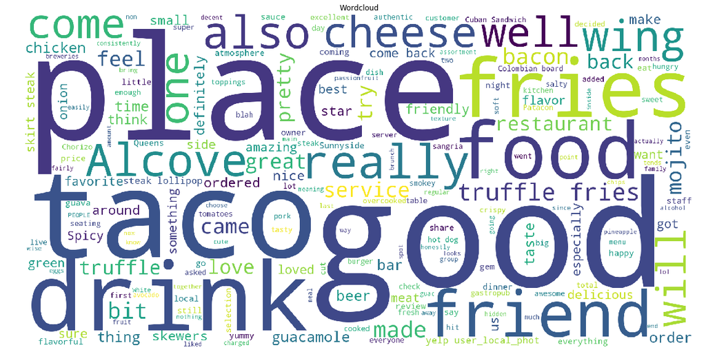

```python
def start(url):
    word_list = []
    source_code = requests.get(url).text
    soup = BeautifulSoup(source_code)
    text=""
    for post_text in soup.findAll('p',{'lang':'en'}):
        content = post_text.get_text()
        text = text+content
        #words = content.lower().split()
        #for each_word in words:
            #word_list.append(each_word)
    #print(text)
    # generate word cloud
    plt.figure(figsize=(20,10))
    wordcloud = WordCloud(background_color='white', mode = "RGB", width = 2000, height=1000).generate(text)
    plt.title("Wordcloud")
    plt.imshow(wordcloud)
    plt.axis("off")
    plt.show()

# main program
start('https://www.yelp.com'+url)
```

Map-Reduce for the web scrapped the reivew file from yelp. There are several steps to achieve the goal of word cloud here. 1st: From the restaurant's webpage in yelp to scrape the reviews from costumers. 2nd: Clean up the scrapped file. Because there are some other characters except words, like: ",./?;;@!# etc... 3rd: Create the dictionary in Python for the word and its countted number.

```python
def start(url):
    word_list = []
    source_code = requests.get(url).text
    soup = BeautifulSoup(source_code)
    for post_text in soup.findAll('p',{'lang':'en'}):
        content = post_text.get_text()
        words = content.lower().split()
        for each_word in words:
            word_list.append(each_word)
    clean_up_list(word_list)

def clean_up_list(word_list):
    clean_word_list = []
    for word in word_list:
        symbols = "!@#$%^&*()_+{}:\"<>?,./;[]"
        for i in range(0, len(symbols)):
            word = word.replace(symbols[i],"")
        if len(word) > 0:
            #print(word)
            clean_word_list.append(word)
    create_dictionary(clean_word_list)

def create_dictionary(clean_word_list):
    word_count ={}
    for word in clean_word_list:
        if word in word_count:
            word_count[word] += 1
        else:
            word_count[word] = 1
    for key, value in sorted(word_count.items(), key=operator.itemgetter(1)):
        print(key, value)

# main program
start('https://www.yelp.com'+url)
```

```
write 1
cozy 1
boyfriend 1
lives 1
block 1
demand 1
solely 1
mix 1
mimosa 1
toast 1
homefries 1
prosciutto 1
benedict 1
mentioned 1
aroundthis 1
such 1
smaller 1
pack 1
makes 1
means 1
they're 1
doing 1
focus 1
locals 1
d 1
guys 1
gotta 1
feeling 1
ok 1
expensive 1
waiter 1
patience 1
help 1
decisionsthe 1
seeing 1
tantalizing 1
pictures 1
steaks 1
attentive 1
slow 1
```

[output cut: 885 more lines]

```
they 26
for 28
with 33
this 34
were 35
but 37
is 39
it 39
of 49
was 66
to 73
i 75
a 86
and 106
the 210
```

```python
# geocode the latitude and longitude of the destination and origin
from geopy.geocoders import Nominatim
geolocator = Nominatim()
origin = geolocator.geocode("2641 John F. Kennedy Blvd, Jersey City")
destination = geolocator.geocode(address)
address_start = {"latitude":origin.latitude,"longitude":origin.longitude}
address_end = {"latitude":destination.latitude,"longitude":destination.longitude}
print(address_start,'\n',address_end)
```

```
{'latitude': 40.6957012, 'longitude': -74.0990966}
 {'latitude': 40.7458838, 'longitude': -73.9151513740302}
```

Google Map Direction from origin to destination. Ask a request to search in google map and output the steps that can lead to the restaurant from your own location. The further development of this part, these descriptions for direction will be converted to voice that can help driver when they are driving.

```python
import json, urllib
from urllib.parse import urlencode
import urllib.request
import googlemaps

start = "2641 John F. Kennedy Blvd, Jersey City"
finish = address

url = 'http://maps.googleapis.com/maps/api/directions/json?%s' % urlencode((
            ('origin', start),
            ('destination', finish)
 ))
ur = urllib.request.urlopen(url)
result = json.load(ur)

for i in range (0, len (result['routes'][0]['legs'][0]['steps'])):
    j = result['routes'][0]['legs'][0]['steps'][i]['html_instructions']
    if '<b>' in j:
        j = j.replace('<b>','')
    if '</b>' in j:
        j = j.replace('</b>','')
    if '</div>' in j:
        j = j.replace('</div>','')
    if '/' in j:
        j = j.replace('/','')
    if '<div style="font-size:0.9em">' in j:
        j = j.replace('<div style="font-size:0.9em">',"\n")
    print(j)
```

```
Head northeast on John F. Kennedy Blvd toward Glenwood Ave
Turn right at the 2nd cross street onto Highland Ave
Turn left onto Bergen Ave
Turn right onto Academy St
Turn left onto Baldwin Ave
Turn right to stay on Baldwin Ave
Take the ramp onto NJ-139 E
Continue onto Holland Tunnel
Partial toll road
Entering New York
Keep left at the fork to continue on Exit 5, follow signs for Canal St
Continue onto Laight St
Turn right onto Canal St
Slight right onto Manhattan BridgeManhattan Bridge Upper Roadway
Take the ramp to Interstate 278Bklyn - Qns Expwy
Merge onto Jay St
Turn right onto Sands St
Merge onto I-278 EBrooklyn Queens Expy via the ramp to Triboro Bridge
Take exit 35 toward I-495 E48 St
Keep right, follow signs for 48 St and merge onto 53rd AveQueens Midtown Expy
Turn left onto 48th St
Turn right onto 47th Ave
Turn left onto 50th St
Turn left at the 1st cross street onto Queens Blvd
Turn right onto 48th St
Turn right at the 1st cross street onto 43rd Ave
Turn left at the 1st cross street onto 49th StHeiser St
Destination will be on the right
```